# Authentic Montessori survey

Wildflower Schools

May 3, 2018

## Overview

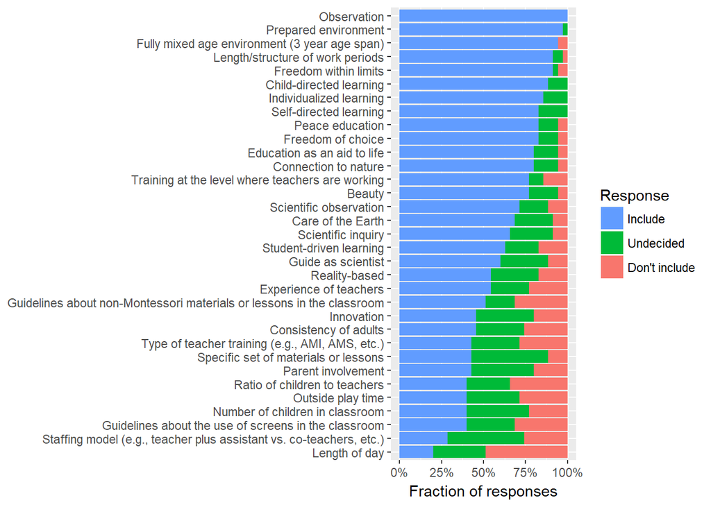

## Individual elements

### Observation

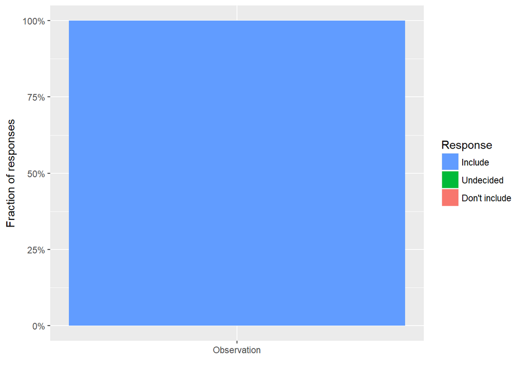

- essential
- Particularly around scientific observation skills that are concrete and mitigate bias.
- Should include that lesson planning is based on observation
- another cornerstone of authentic Montessori in my opinion
- Based on scientific observation
- Crucial
- Important!

### Prepared environment

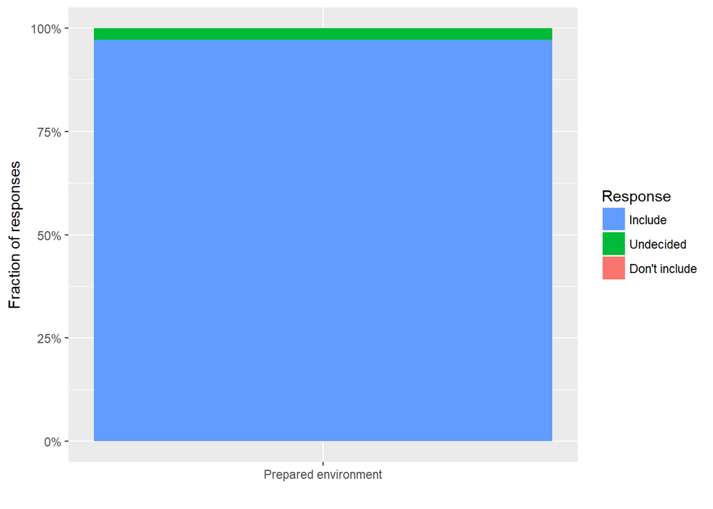

- essential
- This, to me, is a cornerstone of an authentic Montessori classroom.
- This is important, as it is paramount for the children to function freely and independently within the limits the prepared environment creates for them.

### Fully mixed age environment (3 year age span)

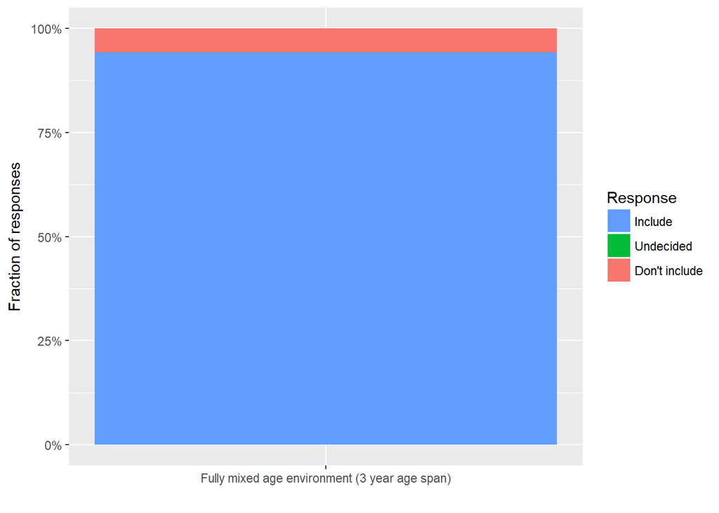

- this is ideal, may nit be true for new classes, public Montessori,etc
- I’m not sure about the word “fully” though.
- Very important– Montessori depends on it!
- Having worked in a public charter where there was a dedicated kindergarten room, it’s important to me to have all three ages groups represented throughout our schools.
- For toddlers, the age span is almost 2 years. Our network schools currently offer 15 - 33 months.
- Super important
- Ideal environment, but it may vary according to actual enrollment. But the goal should be a full mix.

### Length/structure of work periods

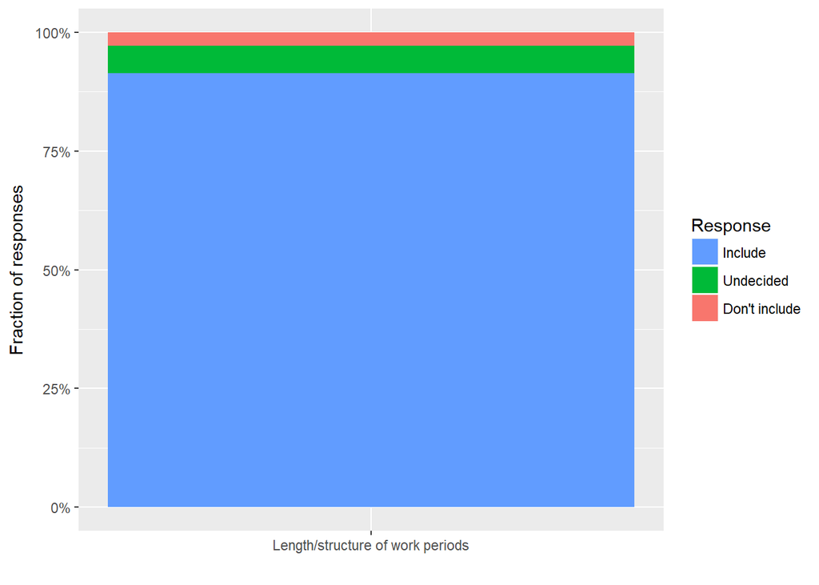

- Changes based on plane.
- Again, the length of work periods is different for toddlers. We use the 2 hour work cycle.
- simple uninterrupted work periods
- I think the 3 hour work cycle is a priority to include.

### Freedom within limits

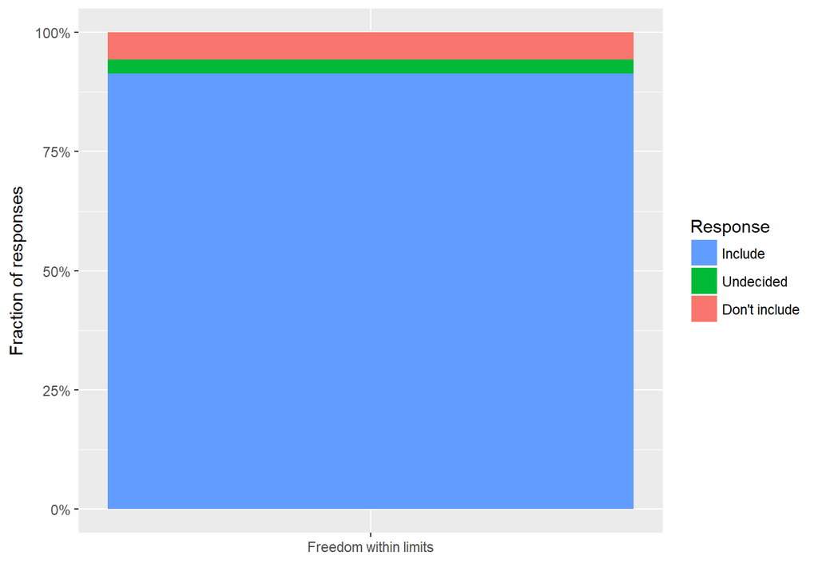

- essential
- This is important, but how will it be phrased? “Children choose their own work”?
- YES!!!!!!!!!!!!!!!! this is one of the biggest areas of confusion when people think about Montessori
- Freedom and responsibility
- An important part of the philosophy, but just trying to think about what you would suss out for “authentic montessori”
- Crucial

### Child-directed learning

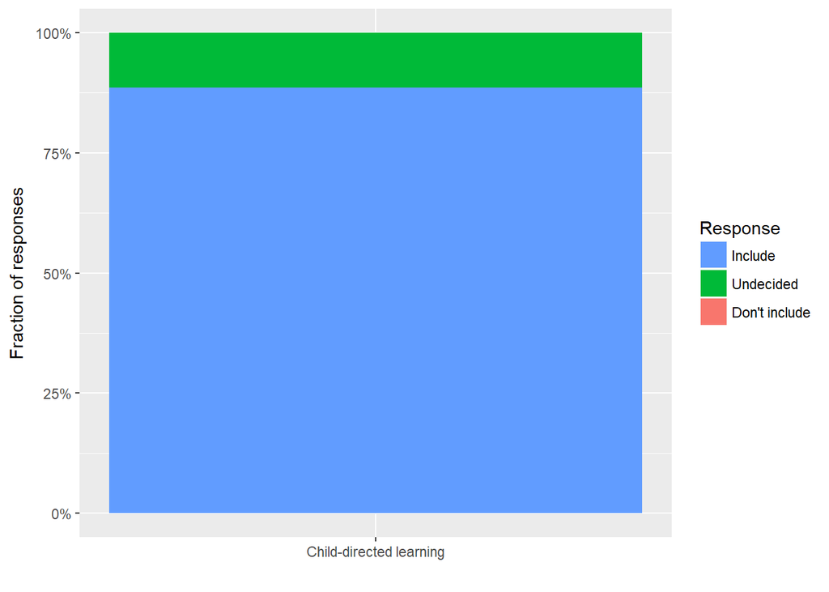

- MOST early childhood programs these days advertise “child-directed learning”. it feels a little “buzzwordy”
- essential
- I really like child-directed, but “young person-directed” doesn’t roll as smoothly and “child-directed” isn’t perfect for the third plane. The concept seems critical, though!
- Crucial

### Individualized learning

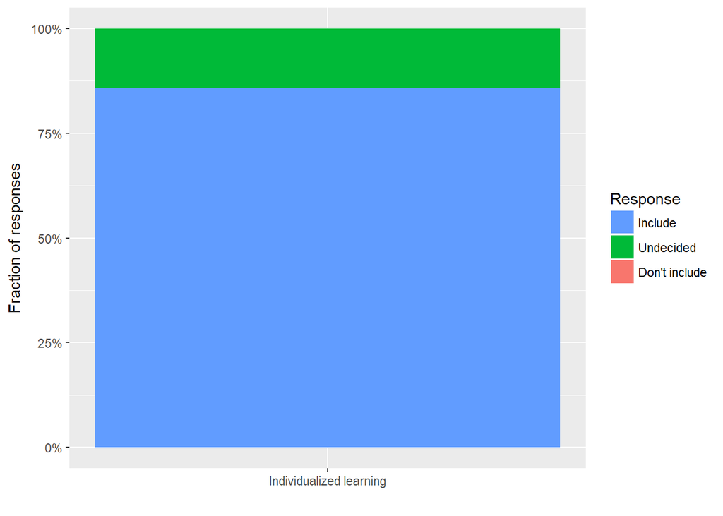

- Important, but not sure the best wording.
- relates to Child Directed Learning
- not sure what that looks like? Does this mean, if we would include one on one lessons for children in our classroom or individualized lessons for children with special needs?

### Self-directed learning

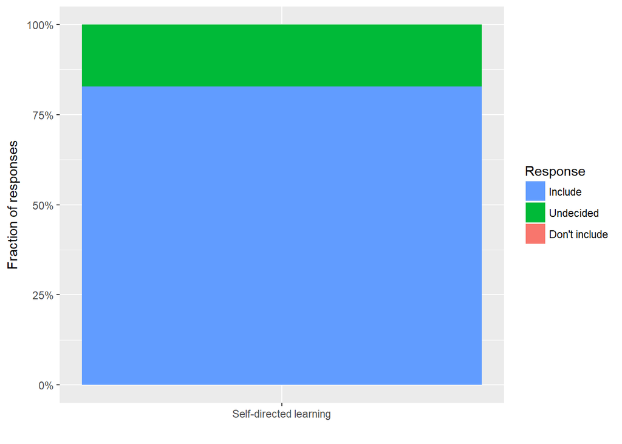

- I like this better than child-directed learning…
- essential
- Important, but not sure the best wording.
- Same a child-directed learning, isn’t it?
- above - child directed learning is checked
- Same as “child-directed learning?” Are you wondering which sounds the best? If so, I like self-directed rather than child-directed.
- Similar to child-directed learning?

### Peace education

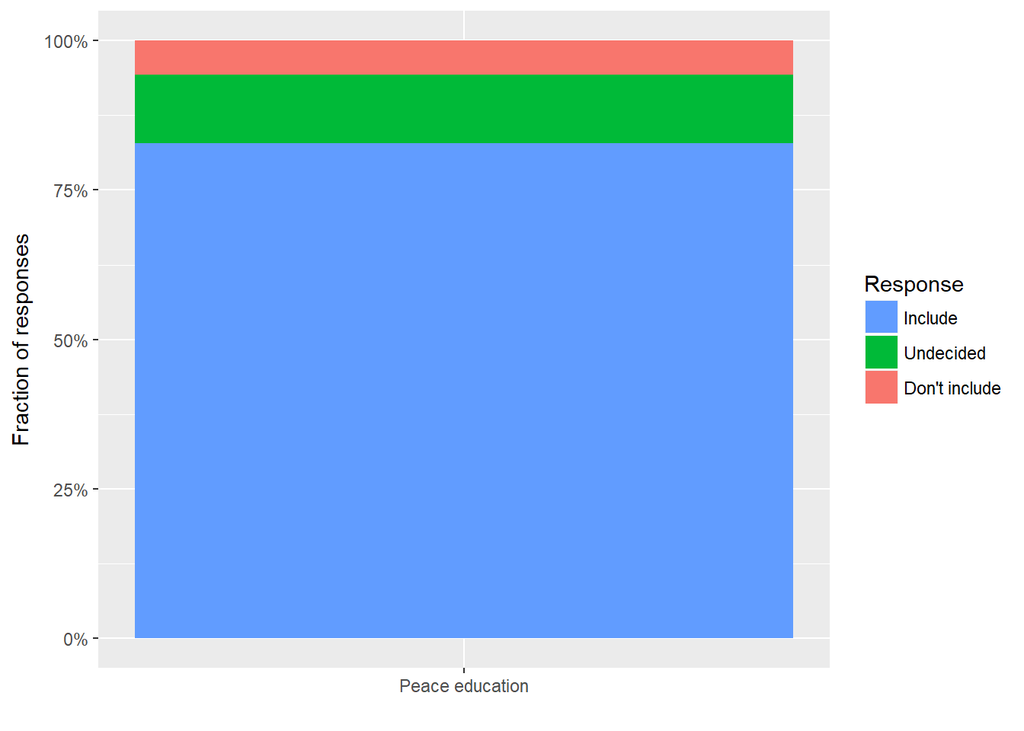

- Important, but not sure the best wording.
- YES! Embracing Equity!
- How are you going to ask this question?
- This one is very important to me
- A cornerstone of Montessori education!!!
- Can’t include everything
- This one is very important - especially right now.
- I would include this, but be flexible and open about what this looks like.

### Freedom of choice

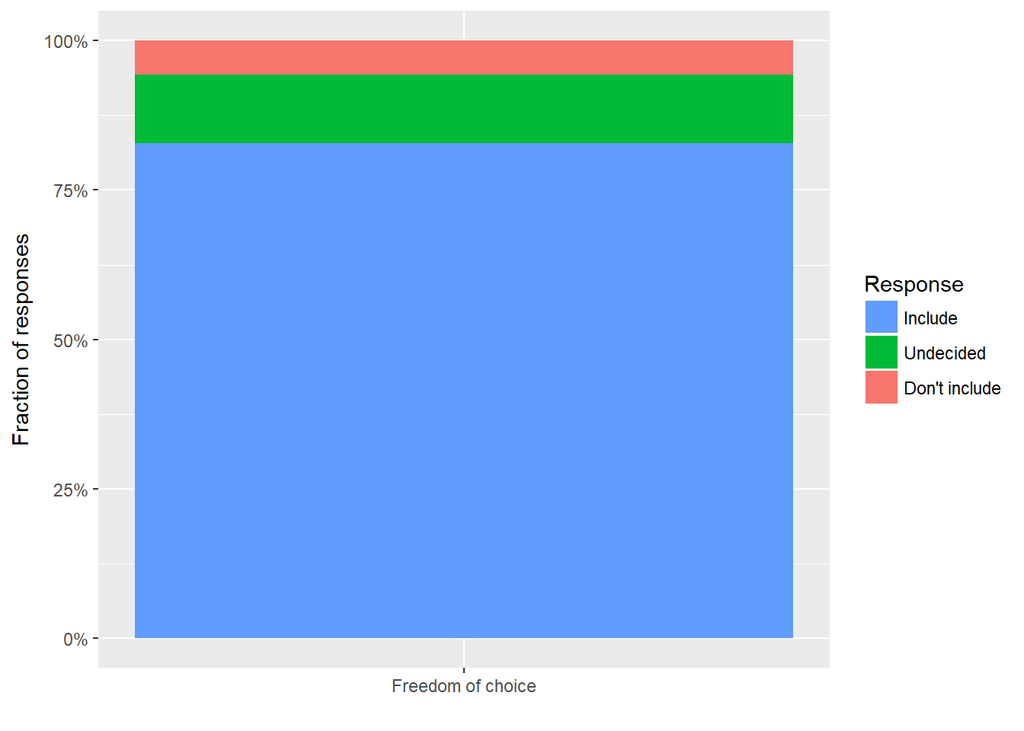

- essential
- Choosing between freedom within limits and freedom of choice? Seems freedom should definitely be there.
- Again, for me this connects with Child Directed Learning
- falls under self-directed
- Dovetails with Freedom and Limits.
- Crucial

### Education as an aid to life

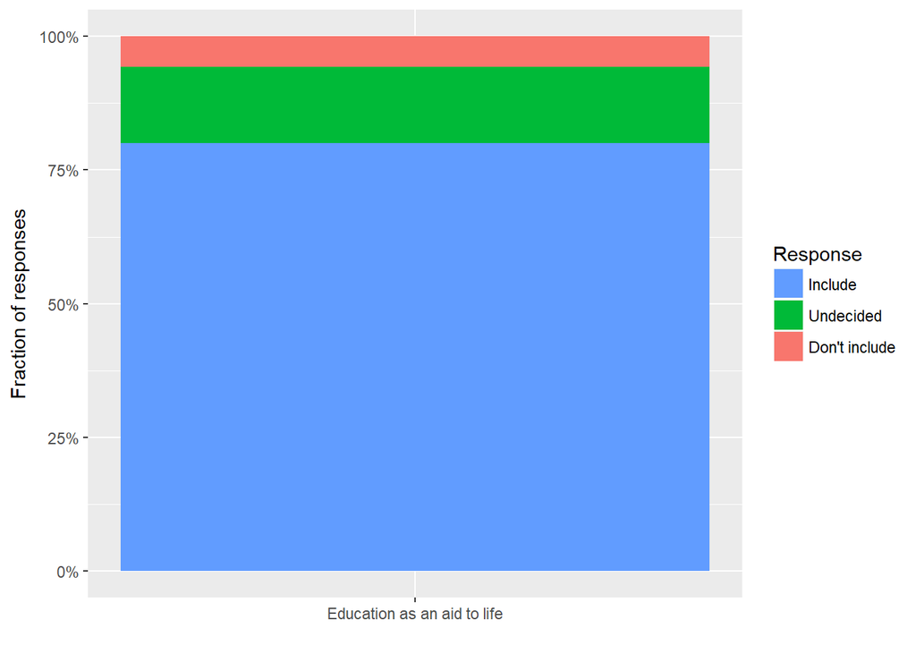

- important at I/T
- For me the intended audience/reader of this informs which elements should be included.
- Don’t know what you mean. Practical life is emphasized?
- YES!

### Connection to nature

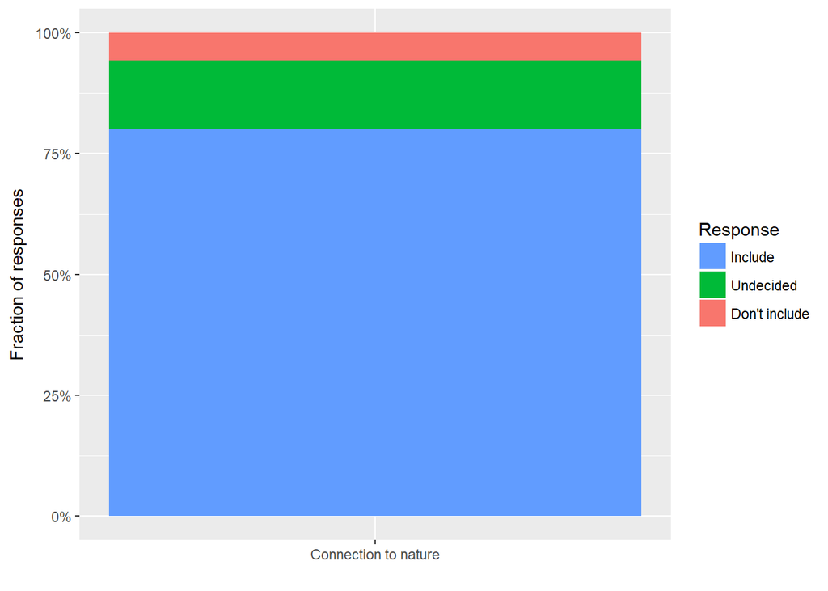

- Again, not sure what you mean. How would you ask the question?
- covered under “nature” principle
- not sure what this means
- Very important!!
- Crucial

### Training at the level where teachers are working

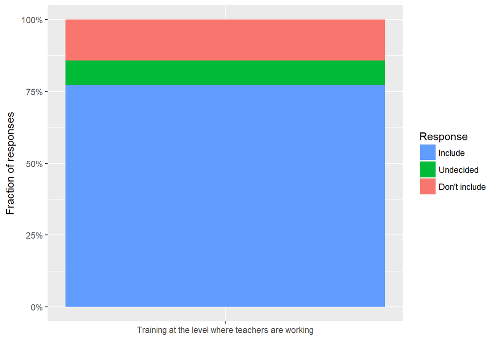

- Im not sure what this means.
- I believe this to be vital
- What would be specified here?
- A complete must!
- This goes without saying and I think the simpler this statement the better.
- Crucial

### Beauty

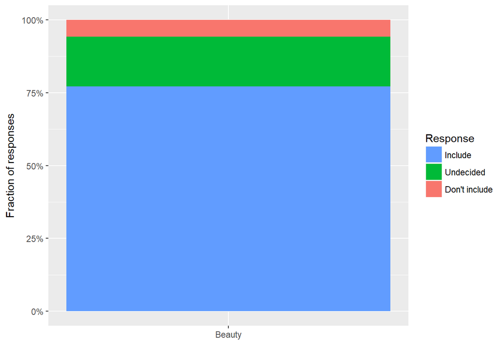

- definitely include.
- Not sure what you mean by this. Beautiful environment? How do you determine this?
- it’s own principle
- A tricky one. Beauty is so subjective. Is there a way to relate this to the environment as a reflection of community culture and equity?
- the environment?
- Just as this principle has evolved, I think that “beauty” is a challenging thing to define in the context of authentic Montessori because it is subjective (i.e. cultural differences)

### Scientific observation

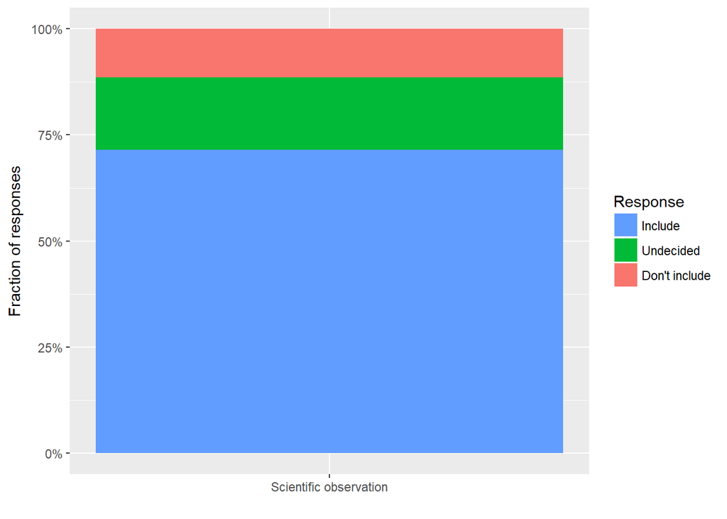

- essential
- I think both scientific inquiry and observation are important, or scientific observation. Are you wondering which is best among those?
- This could be combined with Observation.
- Same as observation, isn’t it?
- not sure if some of these are redundant or could be captured by one of the topics already proposed
- covered under observation
- Maybe this is covered in “observation” & “scientific inquiry?”

### Care of the Earth

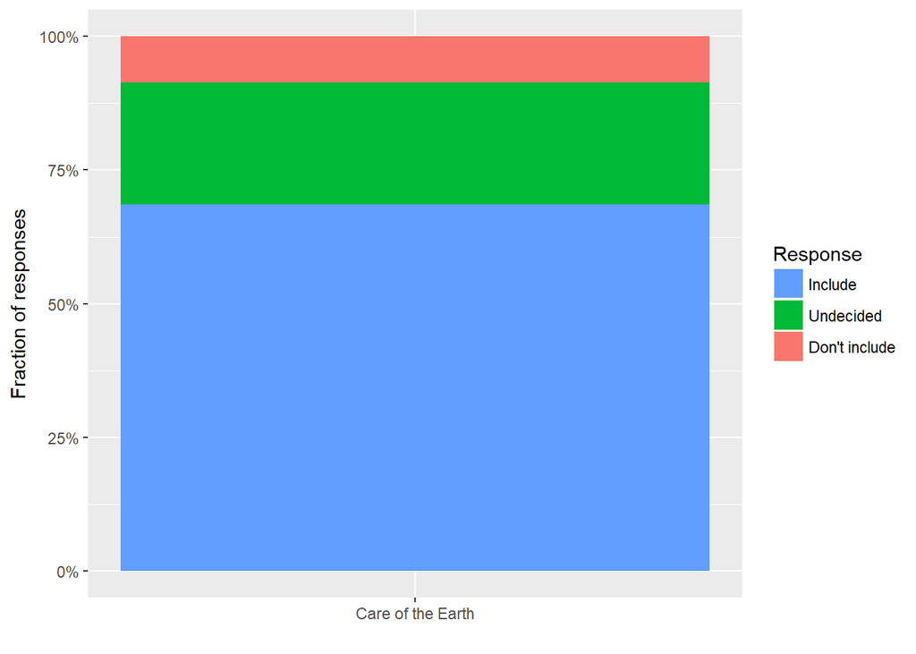

- Important, but not sure the best wording.
- How is this question asked?
- I like this but the wording gets too long if we include things like this - open to discussion

### Scientific inquiry

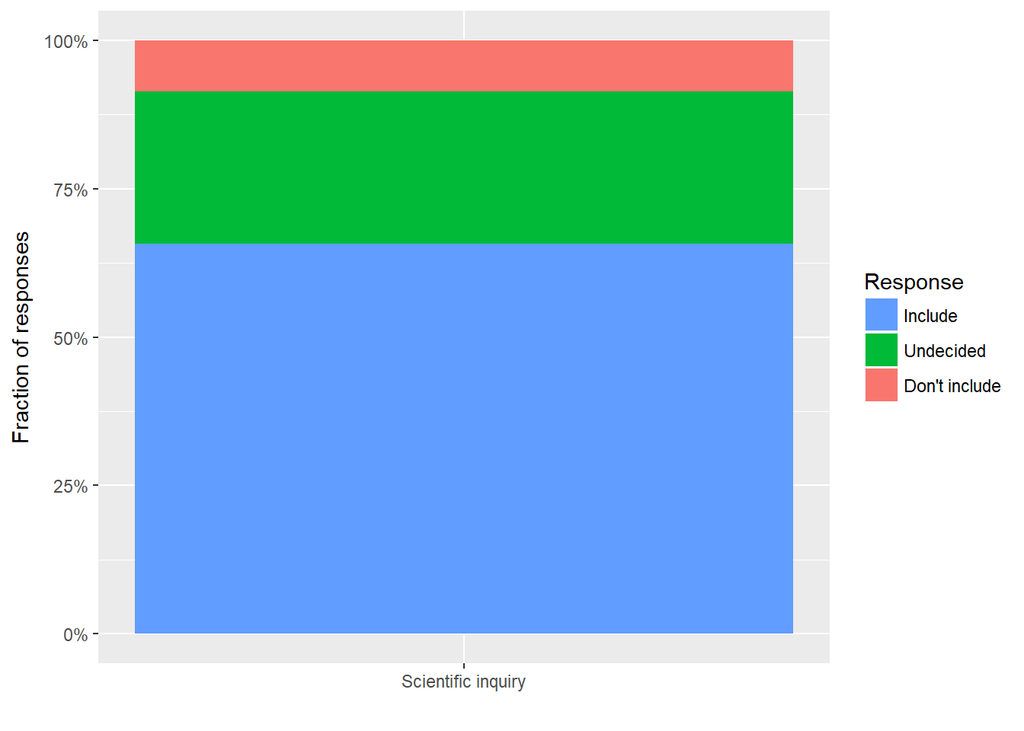

- On the part of the teachers, or the children??
- Not sure what you mean by this
- covered under “lab school” principle?
- This is integral to the Wildflower mission
- I dont understand how this differs from scientific observation
- Not sure what this mean specifically
- For teachers
- Crucial
- Maybe better introduced as scientific research attitude/methods, which can be specified in “observations”, “reports”, “comparison”, “experiment”, etc.

### Student-driven learning

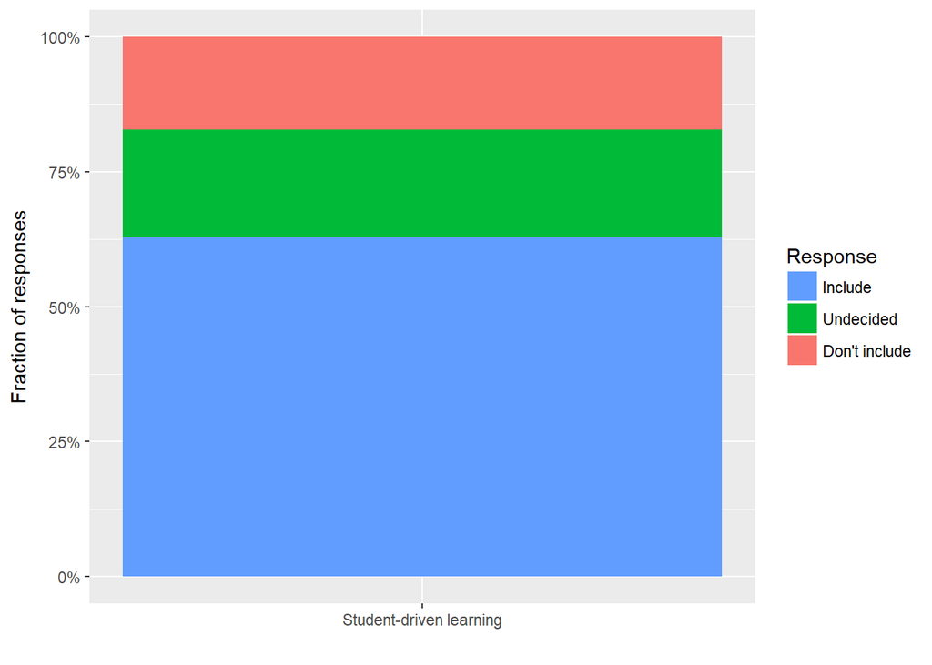

- Again, either child-centered, self-directed, or student-driven should be there, but I’m not sure about the best word choice. I don’t love the word student and the word child isn’t great for the third plane.
- Child Directed Learning…
- Same as other topics already listed
- is this the same as self-directed learning?
- already included
- Covered in “self-directed learning” I think
- child-directed learning sounds better…

### Guide as scientist

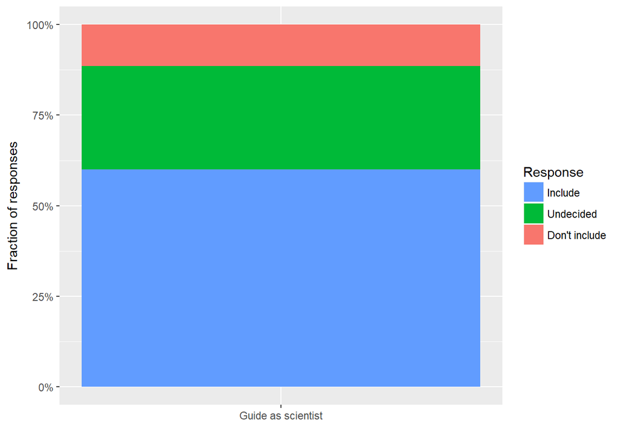

- Important, but not sure the best wording.
- Same as lesson planning based on observation?
- how does this differ from scientific observation? I would not develop this as a separate concept
- same as one of the above questions
- See comments about Scientific inquiries.

### Reality-based

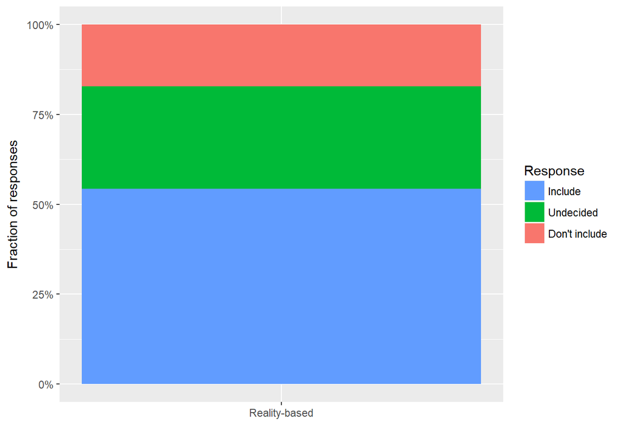

- different at diffferent levels depending on how you interpret
- Important, but not sure the best wording.
- At Primary level only? Elementary is age of imagination.
- I do think that there are times when fiction/picture books are appropriate for young children, so long as they are presented carefully
- Yes please!
- good thought but the definition can’t include eery aspect of Montessori
- There is a misconception that reality-based hinders creativity– so just to clarify around that.

### Experience of teachers

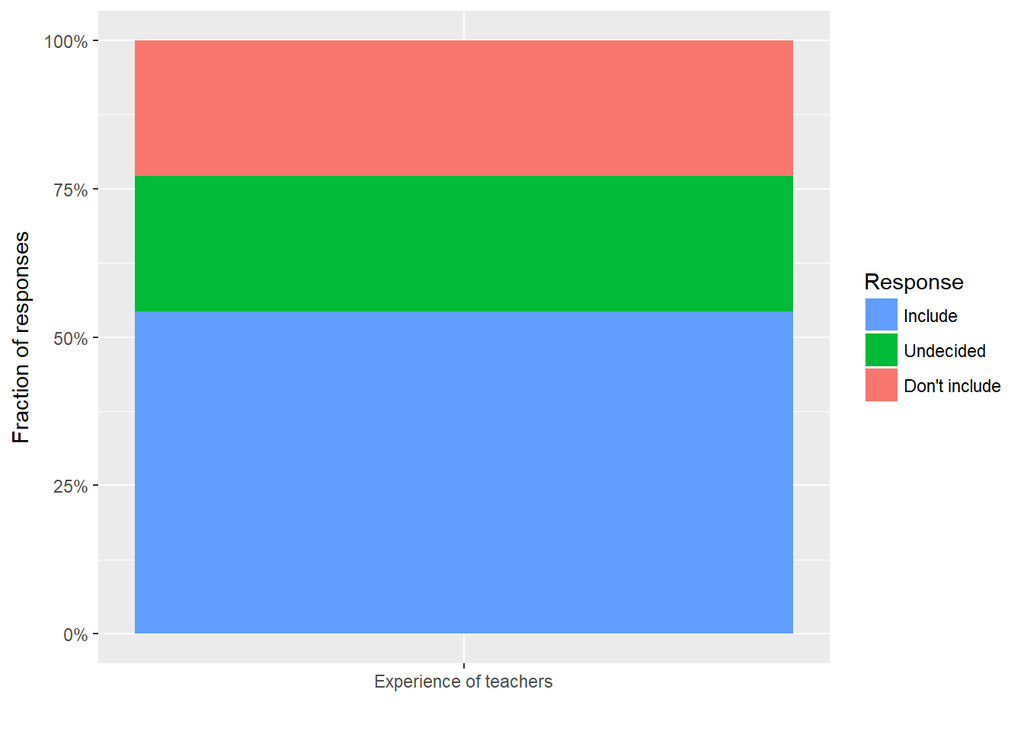

- The teachers should hold Montessori specific credentials (AMI or AMS certifications)
- a class with a 1st year teacher can be an authentic Montessori class
- This is really tricky for the third plane.
- I think having our teams meet a criteria of minimum experience is unique to WF, but again is not necessarily unique to authentic Montessori
- I think its important to note that teachers are authentically trained– AMS or AMI
- I don’t think we should be prohibitive – while we want the highest quality Montessori instruction, experience doesn’t always equate to quality and we have the potential of discouraging emerging teachers off the bat if the experience requirement/recommendations are steep.
- Experience meaning years teaching? Or training?
- I think that experience is a critical component of the success of authentic Montessori.
- A general guideline is useful, I think
- Everyone in our network has different amounts and kinds of experience, as well as different levels of training and degrees. Great teachers come from all kinds of experience levels!
- I don’t think this is necessary
- While it’s optimal to have a very experienced teacher in a classroom, I don’t necessarily think it’s essential. As long as there is a coach/guide involved regularly I think it could go either way.
- I think experience should be an important factor in school endorsement, but not a part of our thoughts on authentic Montessori
- As new teachers with passion, I would want to be given a chance regardless of the amount of experience I have. But I also feel more comfortable if I could work with an experienced co-teacher and learn as I work as a WF school owner. However, once experience became mandatory, it could put a damper on new teachers’ enthusiasm.

### Guidelines about non-Montessori materials or lessons in the classroom

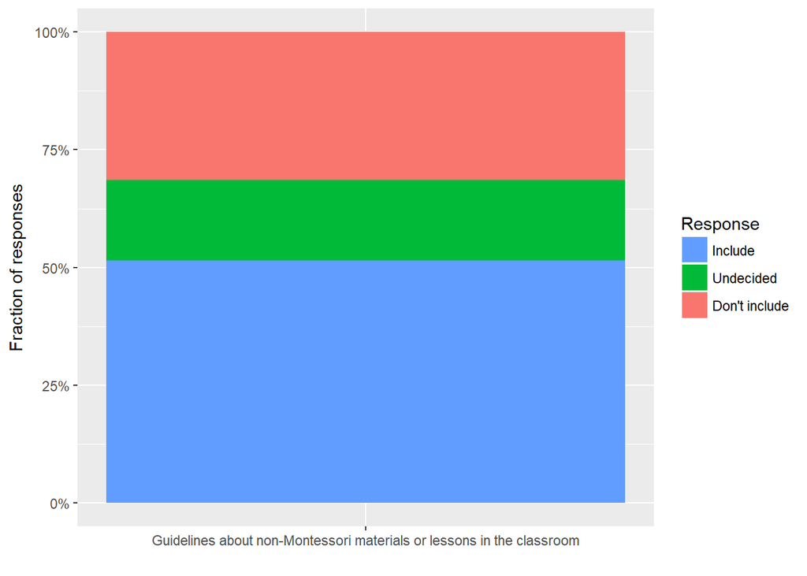

- Again, really challenging for third plane.
- authentic montessori materials
- I’m not sure how we would specify non-montessori materials specifically.
- Seems to fall under the subset of “prepared environment”.
- Some of the most effective/creative language materials I’ve ever seen were not authentic Montessori materials
- Sometimes i bend the “rules” to accommodate the children’s needs. I am guilty of putting a “line” in my toddler classroom, as well as using cylinder blocks. I’d be happy to hear feedback if there are folks who think that this is not a good idea! but yes, in general, our schools should have mostly/only true montessori work out.
- With it being our goal to meet every child where they are, I do believe there are times (especially in the areas of practical life, into to language, and some numeration) where non-Montessori materials are very useful and appropriate.
- I don’t yet have Montessori Primary or Elementary training, so I’m a little unclear on how the community would define non-Montessori materials.
- A guideline is very helpful, which encourages teacher’s creativity and also keep Montessori practice on track.

### Innovation

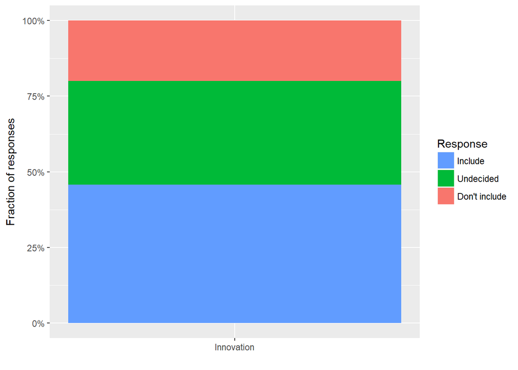

- This is important to be a wildflower school, but not necessarily important to be a Montessori school.
- depends how it would be articulated
- Innovation within the structure of Montessori.
- WF principle
- Again I know this is something we strive for in our schools and in Wildflower but I’m not sure it belongs in Authentic Montessori

### Consistency of adults

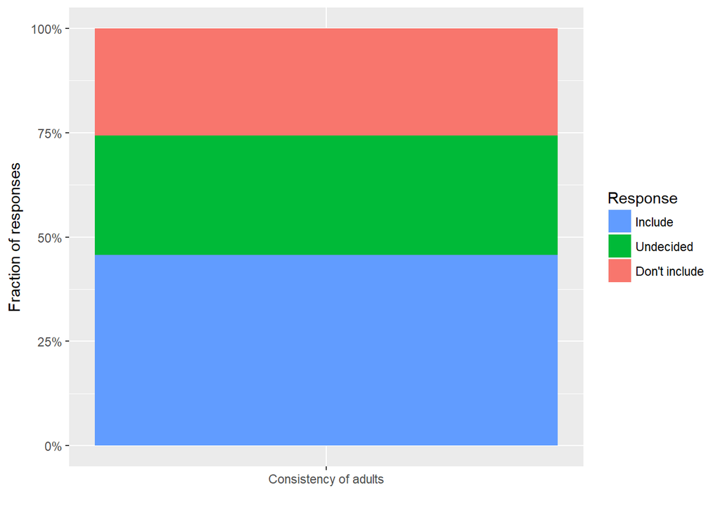

- As in that the same people are in the classroom at the same times or for a certain number of years?
- Isn’t this the same as the teacher model?
- I’m not sure what this means
- Always.
- Don’t know what this refers to
- don’t know what this means
- Yes! I think this is crucial.

### Type of teacher training (e.g., AMI, AMS, etc.)

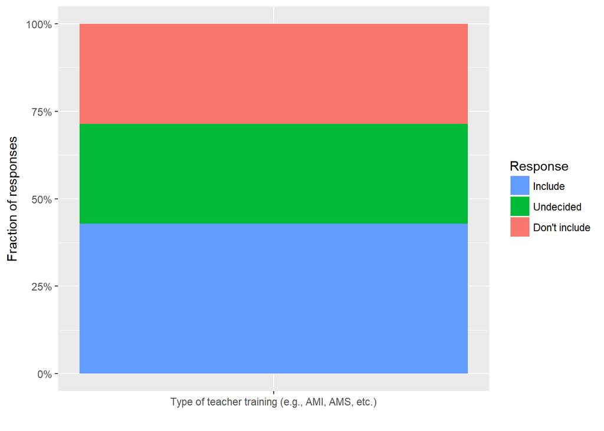

- Either AMI or AMS seems important, right? I’m not knowledgeable enough here to respond with a strong opinion.
- I think isolating what training teachers are allowed to have attended is not inclusive and has the potential to alienate some (like myself and Micki for example- both AMS trained)
- I think Wildflower is a powerful network in that it can rise above the politics within the Montessori world and be welcoming of all Montessori educators with a strong grounding in theory.
- This needs discussion
- Training is important. AMS, AMI, MACTE
- It doesn’t include as long as teachers have a lot of communication. And would be even better if the same classroom has one AMI and one AMS trained teachers.
- Yes, but could include both AMI and AMS
- I think its important we adhere to a guidelines of teachers being trained.
- I believe it’s alienating to tell someone where they need to be trained. So long as the program is accredited by MACTE, I’m fine with it.
- Is this teacher’s credential requirement? Teacher’s without it cannot work at WF Schools?

### Specific set of materials or lessons

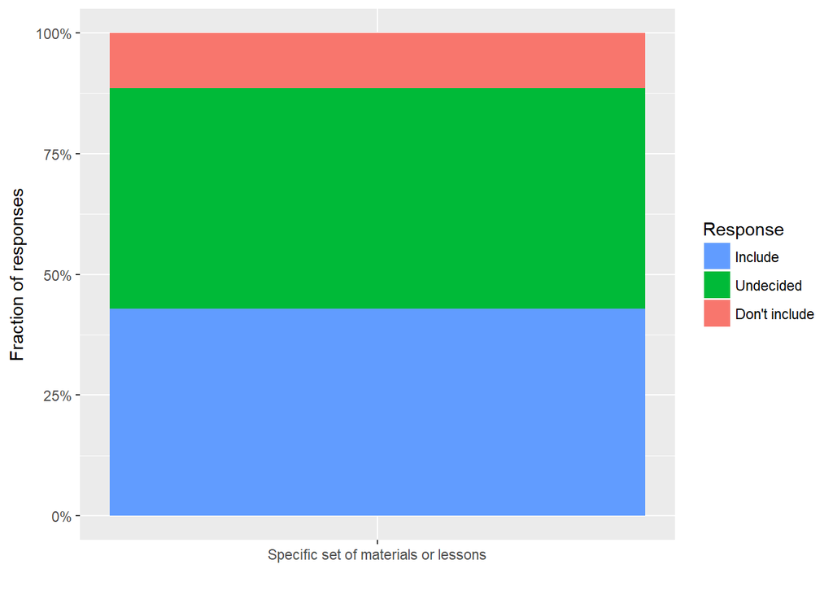

- I would include that the Primary classroom consists of Practical life, Sensorial, Mathematics and Language areas. However, Montessori classrooms should also include lessons in GRace and Courtesy, music, geography, art and biology.
- Challenging for third plane.
- Not sure what this means.
- Not sure what this one is referring to.
- Again, subset of prepared environment
- I’m not sure what exactly this would look like - a guarantee that students would receive certain lessons? Or schools would have certain materials?
- if it is helpful to demonstrate examples
- the specially designed materials are such a part of the Montessori approach
- Many sets are very essential but I believe some can be created/modified by the teachers.
- Follow your album!
- I think I need more clarification on this question. If it means: “Buy all of your materials from Nienhuis” then I don’t agree. If it outlines some of the key lessons/materials that make Montessori what it is, then yes.
- I think it’s nice to leave some flexibility here for creativity.
- It’s helpful to include this for new school’s minimum material cost budgeting, but who decides which set of materials are included?

### Parent involvement

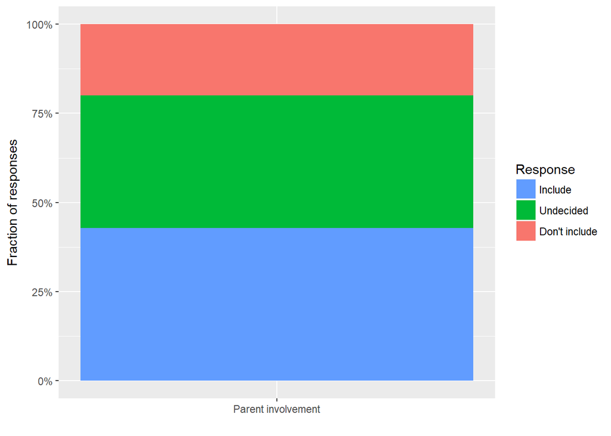

- Not sure it’s needed here to describe “authentic Montessori”–but seems very important in Wildflower culture.
- I’m not sure that this has to do with the definition of Montessori
- Parent involvement (parents in the classroom) is important to e a Wildflower school, but not Montessori
- Every school has slightly different requirements on parent involvement. I think the key here is to get the point across that school is not just a place where parents drop off their kids in teh mornign and pick them up in the afternoon. It is a community we build together!
- Given the WF principles
- Wildflower is unique in the level of parental involvement in the classroom, I think, so this probably should be addressed in this discussion.
- Again, a really important piece of Montessori and WF but what if parents/guardians aren’t around to be involved? Does that make it less Montessori?
- Big piece!

### Ratio of children to teachers

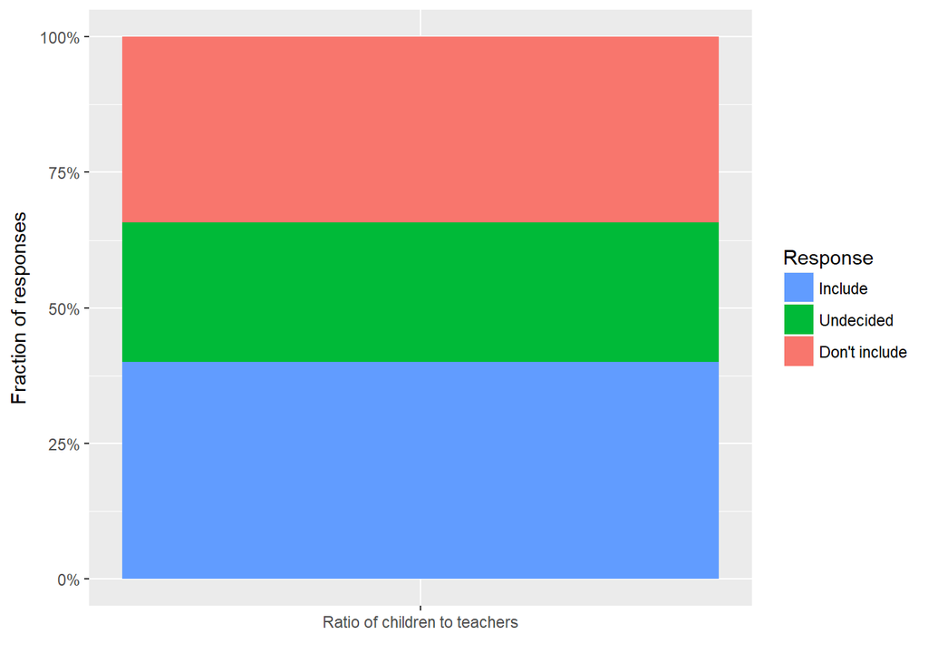

- again - ideal vs special siyuations
- This seems less Montessori and more legal/licensing etc
- Same thoughts as number of students comment.
- This is a tricky one from the standpoint that different environments may need different child/teacher ratios.
- Ration of children to teachers in a toddler classroom is at least 2 adults to 9 children.
- child centered environment and leave the rest to the imagination!
- This is maybe the more salient point than class size.
- This is really a state requirement
- EEC/licensing regulations are often different than Montessori guidelines so not sure about this.
- This seems like it will be hard to codify given licensing regulations.
- Since EEC already has an arbitrary ratio of children and teachers, there is no need to make it more complicated. We could suggest an ideal ratio for Montessori classrooms, but it can be different depending on the physically space, students background and teacher’s experiences.

### Outside play time

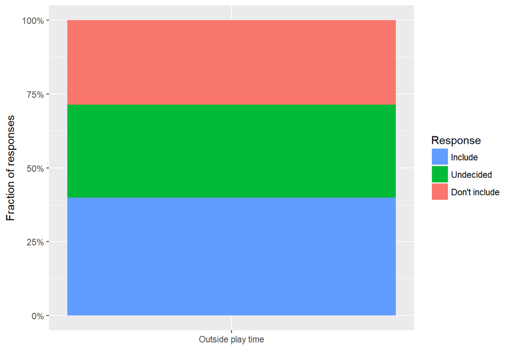

- Time spent outside is important, but specifying an amount of time seems challenging, and the word “play” feels unnecessary to me.
- For me this relates to the connection with nature.
- Everybody should have outside time – does it have to be outside play time?
- what would be specified here?
- Not always necessary. We need to follow the children. If they are focused and working we shouldn’t break that just because we are supposed to go outside. But sometimes we can see they need some outside time.
- Outside time. Not necessarily play time
- I would add time in nature not playtime
- I see this as intimately connected with the connection to nature and think it’s something we should always strive for. I don’t know that it should sit inside a definition of authentic Montssori

### Number of children in classroom

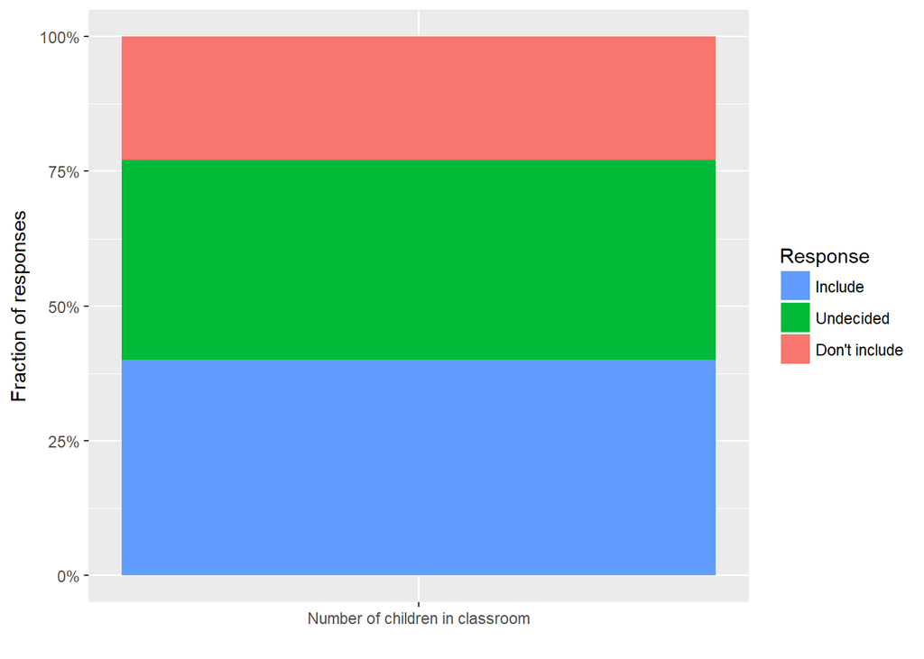

- Again, different for each plane, but a range might work (eg 20 to 35)
- I like this as a goal, but as we know, most schools have not started with the “correct” number of children in the classroom and this may differ slightly from one classroom to the next based on physical space, etc.
- This one seems difficult to provide concrete recommendations as it is so dependent on the age level and the population of students (i.e. number of learning disabilities, behavioral challenges, etc.).
- I think this is an area where AMS and AMI teachers might disagree. I’m open to hearing what everyone has to say.
- I would give a range if we include this
- While this is an important component, lots of WF schools don’t subscribe to the “standard” number of children. Not sure how important this is…
- Should be a large number of children
- We have to own our current EEC requirements, our businesswoman’s wisdom, physical space limitations
- It doesn’t matter to me how many children are in a classroom - small or large, you can still have an authentic Montessori classroom in my opinion.
- This seems like it will be hard to codify given licensing regulations.
- Different schools may have different situations. But any manageable number should not be too big and conscious teachers will be able to draw the line appropriately.

### Guidelines about the use of screens in the classroom

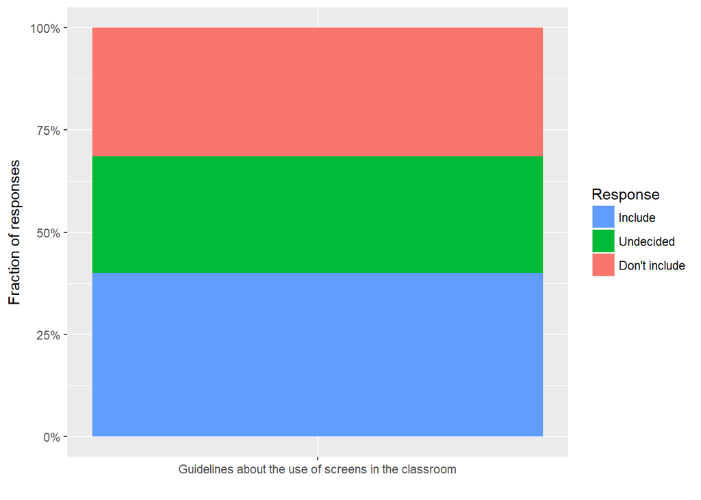

- will use at elementary at times but prefer paper when we can find what we need
- Seems like it will be different for different planes/subplanes…but something about developmentally appropriate use might be good
- While I definitely think that there should be no screens in the classroom, undecided whether it needs to be in the definition of authentic montessori.
- Use of screens by teachers? by students?
- I think this is SUPER important and am undecided about whether this should be in the description. Maybe yes.
- While I think this is a given in the primary classroom, I’m not sure that this is something that needs to be spelled out in the principle.
- I don’t think screens have a place for children in an early childhood classroom, but as children progress through our schools, it definitely plays a role in the upper elementary classroom (and even lower).
- certainly not until elementary
- Would love to hear/read more about this topic.
- Especially since we are focusing on “new technology” for TL’s/guides I think this would be helpful to include and to include parameters.
- Outside of teachers taking photographs or documenting work through transparent classroom, I don’t think there should be any screens in a 3 - 6 classroom. Guidelines to help parents limit screen time outside of the classroom would be helpful.
- I’m not sure if this pertains to authentic Montessori, but I think it would be helpful to address the use of phones/ tablets in the classroom, even when used for pictures.
- Controlled and limited use of screens for educational purpose only. Screens can be the “forbidden apple” if avoided completely. Children can overcompensate the screen time at home. If given proper limits, screen time can be productive and normalized as well.